# Final-Optimal-Modeling-2

# ElasticNet

Scikitlearn impliments a hybrid regularization scheme called "elastic net", the cost function in this case is 𝑅𝑆𝑆(𝛽)+𝜆𝐿1𝑅𝑎𝑡𝑖𝑜∑|𝛽𝑖|+𝜆(1−𝐿1𝑅𝑎𝑡𝑖𝑜)∑𝛽2𝑖

```python
Elastic_regression=linear_model.ElasticNet(fit_intercept=True,alpha=1,l1_ratio=0.1,normalize=True) ## L1 norm is more strong
Elastic_regression=Elastic_regression.fit(X_train,Y_train)
print([Elastic_regression.coef_,Elastic_regression.intercept_])
```

```
[array([ 0., -0., -0.,  0.,  0.,  0.,  0., -0.,  0.,  0., -0., -0.,  0.,
       -0., -0., -0., -0., -0., -0., -0.,  0.,  0.,  0., -0., -0., -0.,
       -0., -0., -0.,  0.,  0.,  0., -0.,  0.,  0.,  0.,  0.,  0.,  0.,
       -0., -0.,  0.]), 39.61458488978276]
```

```python
predictions_elastic = Elastic_regression.predict(X_test)
```

```python
Elastic_regression.score(X_test, Y_test)
```

```
-1.3608501012729588e-06
```

```python
from sklearn.metrics import mean_absolute_error, mean_squared_error, r2_score
mean_absolute_error(Y_test, predictions_elastic)
```

```
9.36563884216386
```

```python
mean_squared_error(Y_test, predictions_elastic)
```

```
138.70773984450003
```

```python
r2_score(Y_test, predictions_elastic)
```

```
-1.360850101272959e-06
```

Here the r2 score is -1.360850101272959e-06

so this model will not help us any more in prediction.

### Ada Boost

```python
ab = AdaBoostRegressor(DecisionTreeRegressor(max_depth=18),n_estimators=20,learning_rate=0.01,random_state=123).fit(X_train, Y_train)
ab
```

```
AdaBoostRegressor(base_estimator=DecisionTreeRegressor(criterion='mse', max_depth=18, max_features=None,
           max_leaf_nodes=None, min_impurity_decrease=0.0,
           min_impurity_split=None, min_samples_leaf=1,
           min_samples_split=2, min_weight_fraction_leaf=0.0,
           presort=False, random_state=None, splitter='best'),
         learning_rate=0.01, loss='linear', n_estimators=20,
         random_state=123)
```

```python
ab.score(X_train, Y_train)
```

```
0.6932883055540973
```

```python
Y_pred = ab.predict(X_test)
```

```python
r2_score(Y_test, Y_pred)
```

```
0.6785537491771214
```

```python
mean_absolute_error(Y_test, Y_pred)
```

```
4.767272143210651
```

```python
np.sqrt(mean_squared_error(Y_test, Y_pred))
```

```
6.6773514402700105
```

Using the ADA boost modeling the

Train data : 69%

Test data : 67%

Sqrt Mean square error : 6.67

Absolute mean error = 4.7

where the model is predicting in good accuracy results with approx 70% with the dataset with 43 features

### DecisionTree

```python
dt = DecisionTreeRegressor(random_state=999,max_depth=18).fit(X_train, Y_train)
```

```python
dt.score(X_train, Y_train)
```

```
0.8009132046938511
```

```python
Y_pred = dt.predict(X_test)
```

```python
r2_score(Y_test, Y_pred)
```

```
0.7890410962694223
```

```python
print('Mean Absolute Error:', metrics.mean_absolute_error(Y_test, Y_pred))
print('Mean Squared Error:', metrics.mean_squared_error(Y_test, Y_pred))
print('Root Mean Squared Error:', np.sqrt(metrics.mean_squared_error(Y_test, Y_pred)))
```

```
Mean Absolute Error: 3.1893492472407097
Mean Squared Error: 24.032442009820357
Root Mean Squared Error: 4.902289466139301
```

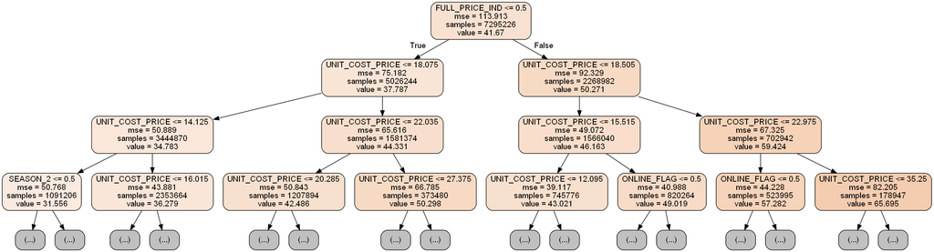

```python
dot_data = export_graphviz(dt, out_file=None, feature_names=X_train.columns,filled=True,rounded=True,max_depth=3)
graph = py.graph_from_dot_data(dot_data)
os.environ["PATH"] += os.pathsep + 'C:/Program Files (x86)/Graphviz2.38/bin/'
tree_image(graph.create_png())
```

### Gradient Booasting

```python
#del dt, rf, ab
```

```python
gb=GradientBoostingRegressor(random_state=100,max_depth=18,n_estimators=20).fit(X_test,Y_test)
gb
```

```python
gb.score(X_test,Y_test)
```

```
0.5977042391381542
```

```python
Y_pred = gb.predict(X_train)
```

```python
r2_score(Y_train, Y_pred)
```

```
0.5952306685770754
```

```python
mean_absolute_error(Y_train, Y_pred)
```

```
5.707893188544996
```

```python
np.sqrt(mean_squared_error(Y_train, Y_pred))
```

```
7.517398867012789
```

Using the Gradient Booasting the

Sqrt Mean square error : 7.51

Absolute mean error = 5.7

where the model is predicting in good accuracy results with approx 60% with the dataset with 43 features

### KNN

```python
knn = KNeighborsRegressor(n_neighbors=4).fit(X_train, Y_train)
```

```python
knn.score(X_train, Y_train)
```

[output not shown]

```python
Y_pred = knn.predict(X_test)
```

```python
r2_score(Y_test, Y_pred)
```

[output not shown]

```python
from sklearn import metrics
print('Mean Absolute Error:', metrics.mean_absolute_error(Y_test, Y_pred))
print('Mean Squared Error:', metrics.mean_squared_error(Y_test, Y_pred))
print('Root Mean Squared Error:', np.sqrt(metrics.mean_squared_error(Y_test, Y_pred)))
```

[output not shown]

```python
zippedList =  list(zip(list(X_test.columns),list(knn.feature_importances_) ))
fi = pd.DataFrame(zippedList, columns = ['feature' , 'Importance'])
fi=fi.sort_values(by='Importance', axis=0, ascending=False, inplace=False, kind='quicksort', na_position='last').head(30)
fi
```

[output not shown]